# Introduction_to_GoogleColab

## What is Google Colab?

Google Colab is a online notebook-like coding environment that is well-suited for machine learning and data analysis.

It comes equipped with many Machine Learning libraries and offers GPU usage. It is mainly used by data scientists and ML engineers.

## Is Google Colab free?

Yes, Google Colab is free to use and you can access all of its features to a certain degree. There is a subscription plan called Google Colab Pro that offers access to upgraded features.

## Why should I use Google Colab?

- Google Colab is Free
- Easy to get started
- Allows access to GPUs/TPUs
- Easy to share code with others
- Easy graphical visualizations in notebooks

Getting started with Google Colab is easy. You don’t need to install any prerequisites or have a decent PC or laptop. All you need is a browser where you’ll get a Jupyter Notebook-like environment.

## How do you use Colab?

To use Colaboratory, you must have a Google account and then access Colaboratory using your account. Since Colab is working on your own Google Drive, you first need to initiate the connection.

In your Google Drive account, click on *More* then *Connect more apps* and find *Colaboratory*, and click install. Once the Google Colab is connected, you will be able to open the jupyter notebook file in the Google Colab.

[figure not shown]

One way is to create new notebook is to go to [this link](https://colab.research.google.com/notebooks/intro.ipynb#recent=true) and click the “New Notebook” button on the bottom right. From the tabs, you can also see that you have access to Google Colab examples, Recent notebooks, Google Drive, GitHub, and you can upload your own notebook.

[figure not shown]

Other way to create a new Colab notebook is to click *New* and drop the menu down to *More* and then select *Google Colaboratory*.

[figure not shown]

You can rename your notebook by clicking on the name of the notebook and changing it, or by dropping the *File* menu down to *Rename*.

[figure not shown]

To open an existing jupyter notebook in Google Colab, click *Open with* > *Google Colaboratory*.

[figure not shown]

When viewing someone's notebook, you usually do not have the right to edit the files. To run the code within that notebook, the file needs to be first copied into your own Google Drive.

[figure not shown]

## Getting started

The document that you are reading is not a static web page, but an interactive environment called a Colab notebook that lets you write and execute code.

```python
print("hello world!")
```

```
hello world!
```

Here, we write a short Python script that computes a value, stores it in a variable and prints the result:

```python
seconds_in_a_day = 24 * 60 * 60
seconds_in_a_day
```

```
86400
```

To execute the code in the above cell, select it with a click and then either press the play button to the left of the code, or use the keyboard shortcut 'Command/Ctrl+Enter'. To edit the code, just click the cell and start editing.

Variables that you define in one cell can later be used in other cells:

```python
seconds_in_a_week = 7 * seconds_in_a_day
seconds_in_a_week
```

```
604800
```

You can also create your own function. This is particularly useful if you would like to run certain code repeatedly with different sets of data.

To create a function, use `def` keyword. You can pass information to the function as arguments. In the following example, we will write a function that sums the two input arguments.

```python
x = 1
y = 4

def addition (arg1, arg2):
  result = arg1+ arg2
  print ('The sum is equal to', result)

addition(x,y)
```

```
The sum is equal to 5
```

Colab notebooks allow you to combine **executable code** and **rich text** in a single document, along with **images**, **HTML**, **LaTeX** and more. When you create your own Colab notebooks, they are stored in your Google Drive account. You can easily share your Colab notebooks with co-workers or friends, allowing them to comment on your notebooks or even edit them. To find out more, see Overview of Colab. To create a new Colab notebook you can use the File menu above, or use the following link: [Create a new Colab notebook](http://colab.research.google.com#create=true).

Colab notebooks are Jupyter notebooks that are hosted by Colab. To find out more about the Jupyter project, see jupyter.org.

You can harness the full power of popular Python libraries to analyse and visualise data. The code cell below uses `numpy` to generate some random data, and uses `matplotlib` to visualise it. To edit the code, just click the cell and start editing. The word that are `highlighted` represents the Python library.

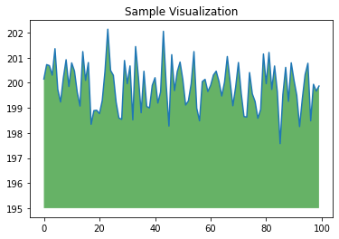

```python
import numpy as np
from matplotlib import pyplot as plt

ys = 200 + np.random.randn(100)
x = [x for x in range(len(ys))]

plt.plot(x, ys, '-')
plt.fill_between(x, ys, 195, where=(ys > 195), facecolor='g', alpha=0.6)

plt.title("Sample Visualization")
plt.show()
```

With Colab you can import datasets, train and evaluate the model, all in just a few lines of code. Colab notebooks execute code on Google's cloud servers, meaning you can leverage the power of Google hardware, including GPUs and TPUs, regardless of the power of your machine. All you need is a browser.

Now, we are ready to jump on [the tutorial](https://colab.research.google.com/drive/1Tn49n0qW178IMDzvXjaLZqmDDFVen6vE?usp=sharing).